# Practical Machine Learning Project Write Up

## Introduction

In this project, data from accelerometers on the belt, forearm, arm, and dumbell of 6 participants who were asked to perform barbell lifts correctly and incorrectly in 5 different ways was used. The goal of the project was to predict the manner in which participants exercised as indicated by the **“classe”** variable in the training set.

## Machine Set Up

Firstly, the working directory is set (not shown) and the required packages are loaded.

```r
sapply(c("data.table",
         "reshape2",
         "doParallel",
         "foreach",
         "caret",
         "randomForest",
         "gbm"),
       require, character.only = T)
```

```
##   data.table     reshape2   doParallel      foreach        caret
##         TRUE         TRUE         TRUE         TRUE         TRUE
## randomForest          gbm
##         TRUE         TRUE
```

Next, I take advantage of my machine’s multiple cores by using parallel processing to speed up some of the following computations.

```r
cl <- makeCluster(detectCores() - 1)
registerDoParallel(cl)
```

## Data Processing

The data is read into R and a simple check is done to ensure that the variables in each set are identical. While the training data has the **“classe”** variable, the testing data has the **“problem_id”** variable.

```r
# Reading the data
training <- fread("Raw Data/pml-training.csv", na.strings = c("", "NA", "#DIV/0!"))
testing <- fread("Raw Data/pml-testing.csv", na.strings = c("", "NA", "#DIV/0!"))

# Check if the test and training datasets contain the same variables
identical(names(testing), names(training))

# Identify the mismatched variables in each dataset
mismatchVarInd <- which(!(names(testing) %in% names(training)))
names(testing)[mismatchVarInd]
names(training)[mismatchVarInd]

# Check if all other variables are equal besides "problem_id" and "classe"
identical(names(testing)[1:159], names(testing)[1:159])
```

```
## [1] FALSE
## [1] "problem_id"
## [1] "classe"
## [1] TRUE
```

An inspection of the training data shows that there are many NA values in several columns. These columns have at least 19216 missing values. Thus, they would not be useful in predicting the outcome of new data. Hence, these columns are removed from both the training and test dataset. Additionally, the first seven columns contain participant details which are unhelpful in prediction. Thus, these columns are also removed. The **“classe”** variable is also converted to factor format.

```r
# Summary of the training data
str(training)

# Count the number of NA values for each field
NAValues <- training[, lapply(.SD, function(x) sum(is.na(x)))]
str(NAValues)

# Proceed to remove those columns of data since they will not be useful for prediction
NAValues <- melt(NAValues)
setkey(NAValues, "value")
NAValues <- NAValues[list(0)]
NAValues <- as.character(NAValues[["variable"]])

# Reminding ourselves that the NAValues vector will contain those variables we want to keep,
# we need to add in the mismatched variable from the test dataset
NAValues <- c(NAValues, names(testing)[mismatchVarInd])

# Proceed to remove unnecessary columns from both the traning and test data set
training[, names(training)[!(names(training) %in% NAValues)] := NULL]
training[, names(training)[1:7] := NULL]
testing[, names(testing)[!(names(testing) %in% NAValues)] := NULL]
testing[, names(testing)[1:7] := NULL]

# Convert the classe column to factor
training[, "classe" := as.factor(classe)]
```

The next step was to check for variables with near zero variance. However, none of the remaining variables were found to have been necessary to remove. Thus, the final training dataset consisted of 52 predictors and 1 outcome variable for a total of 53 columns as shown in the following:

```r
print(nsv <- nearZeroVar(training, saveMetrics = T))
```

```
##                      freqRatio percentUnique zeroVar   nzv
## roll_belt             1.101904     6.7781062   FALSE FALSE
## pitch_belt            1.036082     9.3772296   FALSE FALSE
## yaw_belt              1.058480     9.9734991   FALSE FALSE
## total_accel_belt      1.063160     0.1477933   FALSE FALSE
## gyros_belt_x          1.058651     0.7134849   FALSE FALSE
## gyros_belt_y          1.144000     0.3516461   FALSE FALSE
## gyros_belt_z          1.066214     0.8612782   FALSE FALSE
## accel_belt_x          1.055412     0.8357966   FALSE FALSE
## accel_belt_y          1.113725     0.7287738   FALSE FALSE
## accel_belt_z          1.078767     1.5237998   FALSE FALSE
## magnet_belt_x         1.090141     1.6664968   FALSE FALSE
## magnet_belt_y         1.099688     1.5187035   FALSE FALSE
## magnet_belt_z         1.006369     2.3290184   FALSE FALSE
## roll_arm             52.338462    13.5256345   FALSE FALSE
## pitch_arm            87.256410    15.7323412   FALSE FALSE
## yaw_arm              33.029126    14.6570176   FALSE FALSE
## total_accel_arm       1.024526     0.3363572   FALSE FALSE
## gyros_arm_x           1.015504     3.2769341   FALSE FALSE
## gyros_arm_y           1.454369     1.9162165   FALSE FALSE
## gyros_arm_z           1.110687     1.2638875   FALSE FALSE
## accel_arm_x           1.017341     3.9598410   FALSE FALSE
## accel_arm_y           1.140187     2.7367241   FALSE FALSE
## accel_arm_z           1.128000     4.0362858   FALSE FALSE
## magnet_arm_x          1.000000     6.8239731   FALSE FALSE
## magnet_arm_y          1.056818     4.4439914   FALSE FALSE
## magnet_arm_z          1.036364     6.4468454   FALSE FALSE
## roll_dumbbell         1.022388    84.2065029   FALSE FALSE
## pitch_dumbbell        2.277372    81.7449801   FALSE FALSE
## yaw_dumbbell          1.132231    83.4828254   FALSE FALSE
## total_accel_dumbbell  1.072634     0.2191418   FALSE FALSE
## gyros_dumbbell_x      1.003268     1.2282132   FALSE FALSE
## gyros_dumbbell_y      1.264957     1.4167771   FALSE FALSE
## gyros_dumbbell_z      1.060100     1.0498420   FALSE FALSE
## accel_dumbbell_x      1.018018     2.1659362   FALSE FALSE
## accel_dumbbell_y      1.053061     2.3748853   FALSE FALSE
## accel_dumbbell_z      1.133333     2.0894914   FALSE FALSE
## magnet_dumbbell_x     1.098266     5.7486495   FALSE FALSE
## magnet_dumbbell_y     1.197740     4.3012945   FALSE FALSE
## magnet_dumbbell_z     1.020833     3.4451126   FALSE FALSE
## roll_forearm         11.589286    11.0895933   FALSE FALSE
## pitch_forearm        65.983051    14.8557741   FALSE FALSE
## yaw_forearm          15.322835    10.1467740   FALSE FALSE
## total_accel_forearm   1.128928     0.3567424   FALSE FALSE
## gyros_forearm_x       1.059273     1.5187035   FALSE FALSE
## gyros_forearm_y       1.036554     3.7763735   FALSE FALSE
## gyros_forearm_z       1.122917     1.5645704   FALSE FALSE
## accel_forearm_x       1.126437     4.0464784   FALSE FALSE
## accel_forearm_y       1.059406     5.1116094   FALSE FALSE
## accel_forearm_z       1.006250     2.9558659   FALSE FALSE
## magnet_forearm_x      1.012346     7.7667924   FALSE FALSE
## magnet_forearm_y      1.246914     9.5403119   FALSE FALSE
## magnet_forearm_z      1.000000     8.5771073   FALSE FALSE
## classe                1.469581     0.0254816   FALSE FALSE
```

## Model Building

From theory, the random forest algorithm is a powerful ensemble learning method that would be appropriate for this prediction exercise. However, the question remained as to what was the most appropriate value for the **mtry** tuning parameter. That is, how many variables should be selected at each branch of the tree.

In order to answer the above question, I ran the random forest algorithm through all possible values of **mtry** from 1 to 52 with 10-fold cross validation with the default **ntree** of 500.

```
##     user   system  elapsed
##    65.46     1.35 16799.16
## [1] 9
##   mtry  Accuracy    Kappa   AccuracySD    KappaSD
## 9    9 0.9968402 0.996003 0.0009553842 0.00120877
## [1] 0.3159782
```

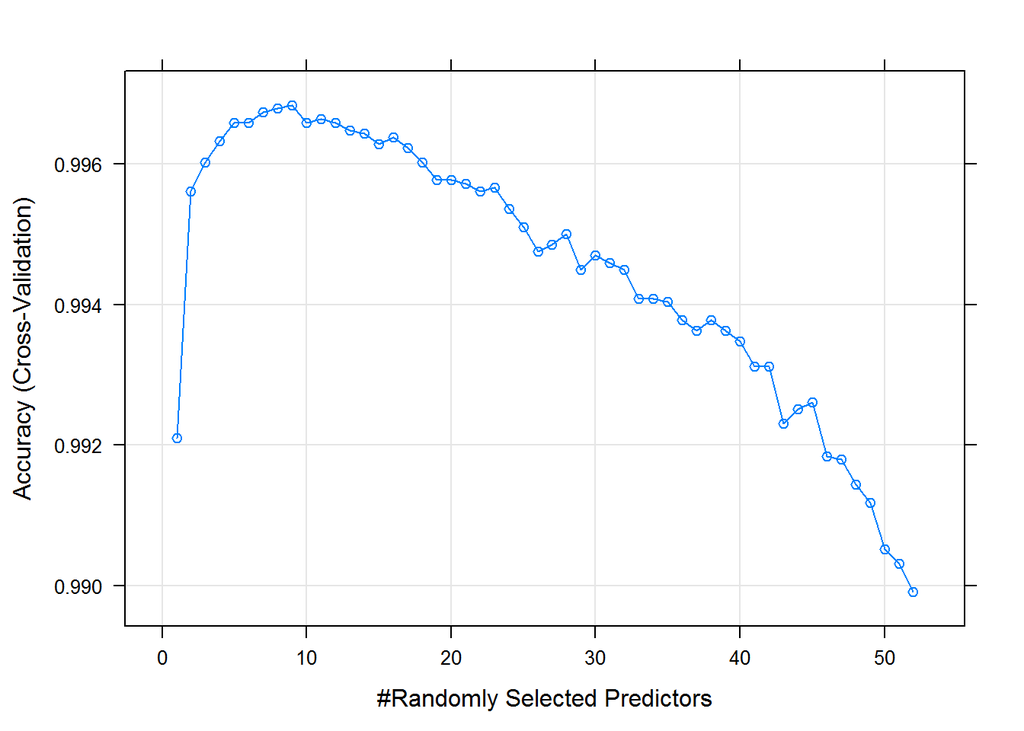

```r
# Search for the best 'mtry' value using 10 fold cross validation
mtryGrid <- 1:52
set.seed(3)
seeds <- c(replicate(10, sample.int(1000, length(mtryGrid)), simplify = F), sample.int(1000, 1))
modelRF <- train(classe ~ .,
                 data = training,
                 method = "rf",
                 trControl = trainControl(method = "cv", seeds = seeds),
                 tuneGrid = data.frame(mtry = mtryGrid))

# The time taken for the entire process
modelRF$times$everything

# Plot of Accuracy versus mtry
plot(modelRF)

# Best mtry is 9 with accuracy
print(mtryBest <- modelRF$bestTune$mtry)
print(mtryBestAccuracy <- modelRF$results[9, ])
print(mtryBestError <- (1 - mtryBestAccuracy[1, 2])*100)
```

From the process and the plot, it is shown that an **mtry** value of 9 is the best. It has an error rate of **0.316%**, making the model a strong one.

Hence, we settle on a random forest model With **mtry** value of 9.

```r
# Build the final model
seeds <- as.list(sample.int(1000, 11))
modelRFFinal <- train(.outcome ~ .,
                      data = training,
                      method = "rf",
                      trControl = trainControl(method = "cv", seeds = seeds),
                      tuneGrid = data.frame(mtry = mtryBest))
modelRFFinal$finalModel
modelRFFinal$times$everything
print(modelRFFinalAccuracy <- modelRFFinal$results)
print(modelRFFinalError <- (1 - modelRFFinalAccuracy[1, 2])*100)
```

```
##
## Call:
##  randomForest(x = x, y = y, mtry = param$mtry)
##                Type of random forest: classification
##                      Number of trees: 500
## No. of variables tried at each split: 9
##
##         OOB estimate of  error rate: 0.3%
## Confusion matrix:
##      A    B    C    D    E  class.error
## A 5578    1    0    0    1 0.0003584229
## B   10 3784    3    0    0 0.0034237556
## C    0   10 3409    3    0 0.0037989480
## D    0    0   20 3193    3 0.0071517413
## E    0    0    1    6 3600 0.0019406709
##    user  system elapsed
##   62.63    0.86  509.45
##   mtry  Accuracy    Kappa  AccuracySD     KappaSD
## 1    9 0.9961777 0.995165 0.002464824 0.003118314
## [1] 0.3822267
```

## Test Data Prediction

Finally, the final model is applied on the test dataset and the results are written into their respective files. The last line of code is to shut off the parallel processing.

```r
# Apply model on test set
predictions <- predict(modelRFFinal, testing)

# Load function to write answers
pml_write_files = function(x){
    n = length(x)
    for(i in 1:n){
        filename = paste0("problem_id_",i,".txt")
        write.table(x[i],file=filename,quote=FALSE,row.names=FALSE,col.names=FALSE)
    }
}

# Write prediction answers
pml_write_files(predictions)

# Stop the cluster
stopCluster(cl)
```